# S9_Informe

# INTRODUCCIÓN

## RELEVANCIA

Sabemos que hoy en día las personas están muy interesadas en adquirir un automóvil debido al creciente aumento de la población y la necesidad de poderse movilizar, dado esto las personas se ven interesados en adquirir autos usados ya que estos son mas económicos y de un mayor alcance para la población. Por este motivado en el estudio a realizar se brindara la información relevante sobre la repercusión de los precios asignados a los autos a causa los componentes y características que estos posean.

# DATOS

## PROCESO DE RECOLECCION DE DATOS:

Los datos se obtuvieron de una pagina de internet denominada con el nombre de Kaggle, la cual es una comunidad en línea de científicos de datos y profesionales del aprendizaje automático . Kaggle permite a los usuarios encontrar y publicar conjuntos de datos, explorar y crear modelos en un entorno de ciencia de datos basado en la web, preferimos hacerlo de esta manera debido a que esto nos permite tener menor sesgo en la obtención de los datos, además de que Kaggle es una pagina muy segura y de buen prestigio.

## POBLACION,MUESTRA Y MUESTREO:

### POBLACION

La población de estudio con la cual se trabaja son automóviles usados los cuales son transportados y vendidos en los países de Latinoamerica

### UNIDAD MUESTRAL

La unidad muestral que se tomo son automóviles usados de marcas reconocidas y comerciales tales como: Toyota, Nissan, Audi, BMW, Honda, Esquivar, Isuzu, Jaguar, Mazda, etc. El tamaño de la muestra es de 22 tipos de autos, los cuales poseen 12 variables entre características y partes del auto, y 164 filas.

### TIPO DE MUESTREO:

El tipo de muestreo que se uso es el de muestreo aleatorio simple.

## VARIABLES

### PRESENTACION DE VARIABLES DE ESTUDIO

Para el proyecto que se esta realizando no se utilizaran las variables en un 100%, solo se usaran aquellas que sean de relevancia para el estudio. A continuación se muestra una tabla con las variables a trabajar y sus respectivas definiciones correspondientes.

| Nombre de Variable | Descripción | Tipo de Variable | Restricciones |
| --- | --- | --- | --- |
| soat_promedio | soat promedio | numérica discreta | número entero no negativo |
| fabricante | fabricante | categórica nominal | no presenta restricción |
| tipo_carroceria | tipo de carrocería | categórica nominal | no presenta restricción |
| largo | largo del auto | numérica continua | número no negativo |
| ancho | ancho del auto | numérica continua | número no negativo |
| alto | alto del auto | numérica continua | número no negativo |
| tipo_de_motor | tipo de motor | categórica nominal | no presenta restricción |
| tamanho_motor | tamaño de motor | numérica continua | número no negativo |
| caballo_de_fuerza | caballos de fuerza-potencia | numérica discreta |  |
| precio_carro | precio del carro | numérica continua | número no negativo |
| L_ciudad/100km | litros consumidos en ciudad cada 100 km | numérica continua | número no negativo |
| L_campo/100km | litros consumidos en campo cada 100 km | numérica continua | número no negativo |

## LIMPIEZA DE BASE DE DATOS

Cargamos las librerías para leer los datos.

```r
library(ggplot2)
library(magrittr)
library(readr)
library(dplyr)
library(vctrs)
```

la base de datos autosUsados:

```r
autosUsados <- read_csv("usedcars_dataset.CSV")
head(autosUsados)
```

| symboling | normalized-losses | make | aspiration | num-of-doors | body-style | drive-wheels | engine-location | wheel-base | length | width | height | curb-weight | engine-type | num-of-cylinders | engine-size | fuel-system | bore | stroke | compression-ratio | horsepower | peak-rpm | city-mpg | highway-mpg | price | city-L/100km | highway-L/100km | price_binned | diesel | gas | … |
| --- | --- | --- | --- | --- | --- | --- | --- | --- | --- | --- | --- | --- | --- | --- | --- | --- | --- | --- | --- | --- | --- | --- | --- | --- | --- | --- | --- | --- | --- | --- |
| 3 | NA | alfa-romero | std | two | convertible | rwd | front | 88.6 | 168.8 | 64.1 | 48.8 | 2548 | dohc | four | 130 | mpfi | 3.47 | 2.68 | 9.0 | 111 | 5000 | 21 | 27 | 13495 | 11.190476 | 8.703704 | Low | 0 | 1 | … |
| 3 | NA | alfa-romero | std | two | convertible | rwd | front | 88.6 | 168.8 | 64.1 | 48.8 | 2548 | dohc | four | 130 | mpfi | 3.47 | 2.68 | 9.0 | 111 | 5000 | 21 | 27 | 16500 | 11.190476 | 8.703704 | Low | 0 | 1 | … |
| 1 | NA | alfa-romero | std | two | hatchback | rwd | front | 94.5 | 171.2 | 65.5 | 52.4 | 2823 | ohcv | six | 152 | mpfi | 2.68 | 3.47 | 9.0 | 154 | 5000 | 19 | 26 | 16500 | 12.368421 | 9.038462 | Low | 0 | 1 | … |
| 2 | 164 | audi | std | four | sedan | fwd | front | 99.8 | 176.6 | 66.2 | 54.3 | 2337 | ohc | four | 109 | mpfi | 3.19 | 3.40 | 10.0 | 102 | 5500 | 24 | 30 | 13950 | 9.791667 | 7.833333 | Low | 0 | 1 | … |
| 2 | 164 | audi | std | four | sedan | 4wd | front | 99.4 | 176.6 | 66.4 | 54.3 | 2824 | ohc | five | 136 | mpfi | 3.19 | 3.40 | 8.0 | 115 | 5500 | 18 | 22 | 17450 | 13.055556 | 10.681818 | Low | 0 | 1 | … |
| 2 | NA | audi | std | two | sedan | fwd | front | 99.8 | 177.3 | 66.3 | 53.1 | 2507 | ohc | five | 136 | mpfi | 3.19 | 3.40 | 8.5 | 110 | 5500 | 19 | 25 | 15250 | 12.368421 | 9.400000 | Low | 0 | 1 | … |

#LIMPIEZA DE DATOS

Primero normalizamos el nombre de las variables.

```r
#cambiar nombre de variables
autosUsados <-autosUsados %>%
   rename(soat_promedio=`normalized-losses`, fabricante=make,tipo_carroceria=`body-style`,largo=length, ancho=width, alto=height, tipo_de_motor= `engine-type`, caballo_de_fuerza=`horsepower`, tamanho_motor=`engine-size`, precio_carro=price, `L_ciudad/100km`=`city-L/100km`,`L_campo/100km`=`highway-L/100km`)
```

Creamos un nuevo data frame el cual se deriva de autosUsados,al cual nombraremos autosUsados_cNA el cual abarcara todas las observaciones,aun cuando tenga NAs.Haciendo uso del comando select() de dplyr:

```r
autosUsados %>% select(soat_promedio,fabricante,tipo_carroceria,largo, ancho, alto, tipo_de_motor,caballo_de_fuerza,tamanho_motor,precio_carro,`L_ciudad/100km`,`L_campo/100km`)->autosUsados_cNA
```

El data frame autosUsados_cNA

```r
head(autosUsados_cNA)
```

| soat_promedio | fabricante | tipo_carroceria | largo | ancho | alto | tipo_de_motor | caballo_de_fuerza | tamanho_motor | precio_carro | L_ciudad/100km | L_campo/100km |
| --- | --- | --- | --- | --- | --- | --- | --- | --- | --- | --- | --- |
| NA | alfa-romero | convertible | 168.8 | 64.1 | 48.8 | dohc | 111 | 130 | 13495 | 11.190476 | 8.703704 |
| NA | alfa-romero | convertible | 168.8 | 64.1 | 48.8 | dohc | 111 | 130 | 16500 | 11.190476 | 8.703704 |
| NA | alfa-romero | hatchback | 171.2 | 65.5 | 52.4 | ohcv | 154 | 152 | 16500 | 12.368421 | 9.038462 |
| 164 | audi | sedan | 176.6 | 66.2 | 54.3 | ohc | 102 | 109 | 13950 | 9.791667 | 7.833333 |
| 164 | audi | sedan | 176.6 | 66.4 | 54.3 | ohc | 115 | 136 | 17450 | 13.055556 | 10.681818 |
| NA | audi | sedan | 177.3 | 66.3 | 53.1 | ohc | 110 | 136 | 15250 | 12.368421 | 9.400000 |

```r
View(autosUsados_cNA)
```

En el base de datos autosUsados_cNA :

Podemos observar la cantidad de datos faltantes en la base de datos:

```r
NAs<-sum(is.na(autosUsados_cNA))
NAs
```

```
## [1] 39
```

Podemos observar la cantidad de observaciones incompletas en la base de datos:

```r
sum(!complete.cases(autosUsados_cNA))
```

```
## [1] 37
```

```r
round((NAs/(nrow(autosUsados_cNA)*ncol(autosUsados_cNA)))*100,2)
```

```
## [1] 1.62
```

Calculamos los datos faltantes por cada variable para poder observar como esta afectando los NA afectan a cada una de ellas.

```r
colSums(is.na(autosUsados_cNA))
```

```
##     soat_promedio        fabricante   tipo_carroceria             largo
##                37                 0                 0                 0
##             ancho              alto     tipo_de_motor caballo_de_fuerza
##                 0                 0                 0                 2
##     tamanho_motor      precio_carro    L_ciudad/100km     L_campo/100km
##                 0                 0                 0                 0
```

```r
autosUsados_sNA<-(na.omit(autosUsados_cNA))

head(autosUsados_sNA)
```

| soat_promedio | fabricante | tipo_carroceria | largo | ancho | alto | tipo_de_motor | caballo_de_fuerza | tamanho_motor | precio_carro | L_ciudad/100km | L_campo/100km |
| --- | --- | --- | --- | --- | --- | --- | --- | --- | --- | --- | --- |
| 164 | audi | sedan | 176.6 | 66.2 | 54.3 | ohc | 102 | 109 | 13950 | 9.791667 | 7.833333 |
| 164 | audi | sedan | 176.6 | 66.4 | 54.3 | ohc | 115 | 136 | 17450 | 13.055556 | 10.681818 |
| 158 | audi | sedan | 192.7 | 71.4 | 55.7 | ohc | 110 | 136 | 17710 | 12.368421 | 9.400000 |
| 158 | audi | sedan | 192.7 | 71.4 | 55.9 | ohc | 140 | 131 | 23875 | 13.823529 | 11.750000 |
| 192 | bmw | sedan | 176.8 | 64.8 | 54.3 | ohc | 101 | 108 | 16430 | 10.217391 | 8.103448 |
| 192 | bmw | sedan | 176.8 | 64.8 | 54.3 | ohc | 101 | 108 | 16925 | 10.217391 | 8.103448 |

# ANALISIS DESCRIPTIVOS

## Primera Variable (Soat_Promedio):

### Descriptores numéricos:

```r
summary(autosUsados_sNA$soat_promedio)
```

```
##    Min. 1st Qu.  Median    Mean 3rd Qu.    Max.
##      65      94     115     122     150     256
```

Media->podemos observar que los datos estan alrededor de 122. Mediana->podemos observar que al menos la mitad de los datos son mayores o iguales 115. 3re Quantil-> 75% de los datos es menor que o igual a 150. Min->el minimo valor es 65. Max->el máximo valor es 256.

#### Hallamos los quartiles:

```r
quantile(autosUsados_sNA$soat_promedio)
```

```
##   0%  25%  50%  75% 100%
##   65   94  115  150  256
```

Podemos observar que la mediana siempre será igual al cuartil del 50% o al segundo cuartil. #### Valores Atípicos:

```r
boxplot.stats(autosUsados_sNA$soat_promedio)
```

```
## $stats
## [1]  65  94 115 150 231
##
## $n
## [1] 164
##
## $conf
## [1] 108.0909 121.9091
##
## $out
## [1] 256
```

### Descriptores Gráficos:

####Diagrama de caja:

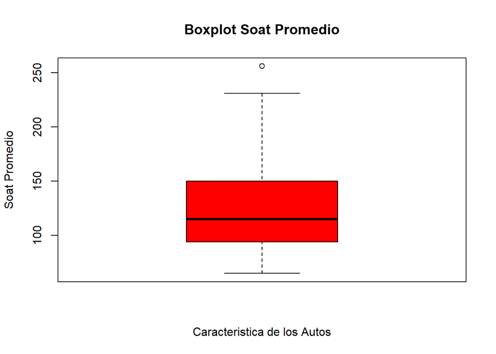

```r
boxplot(autosUsados_sNA$soat_promedio, ylab="Soat Promedio", xlab="Caracteristica de los Autos", main="Boxplot Soat Promedio", col = "red" )
```

## Cuarta Variable (Largo):

### Descriptores numéricos:

```r
summary(autosUsados_sNA$largo)
```

```
##    Min. 1st Qu.  Median    Mean 3rd Qu.    Max.
##   141.1   165.7   172.0   172.2   177.8   202.6
```

Media->podemos observar que los datos estan alrededor de 172.2. Mediana->podemos observar que al menos la mitad de los datos son mayores o iguales 172. 3re Quantil-> 75% de los datos es menor que o igual a 177,8. Min->el minimo valor es 141.1. Max->el máximo valor es 202.6.

#### Hallamos los quartiles:

```r
quantile(autosUsados_sNA$largo)
```

```
##      0%     25%     50%     75%    100%
## 141.100 165.675 172.000 177.800 202.600
```

Podemos observar que la mediana siempre será igual al cuartil del 50% o al segundo cuartil. #### Valores Atípicos:

```r
boxplot.stats(autosUsados_sNA$largo)
```

```
## $stats
## [1] 150.00 165.65 172.00 177.80 192.70
##
## $n
## [1] 164
##
## $conf
## [1] 170.501 173.499
##
## $out
## [1] 141.1 144.6 144.6 199.6 202.6
```

### Descriptores Gráficos:

####Diagrama de caja:

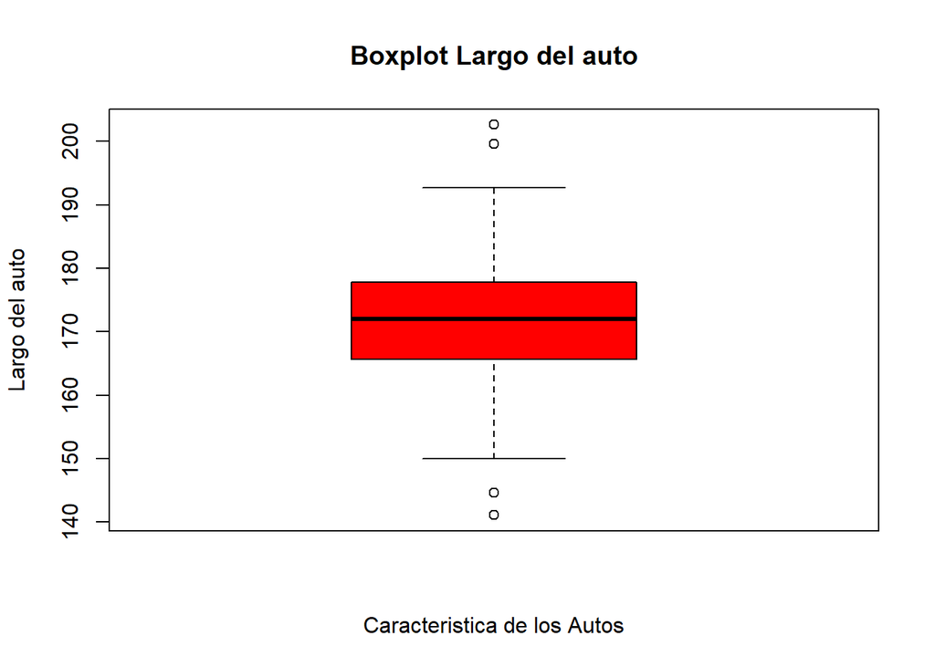

```r
boxplot(autosUsados_sNA$largo, ylab="Largo del auto", xlab="Caracteristica de los Autos", main="Boxplot Largo del auto", col = "red" )
```

## Quinta Variable (Ancho): ### Descriptores numéricos:

```r
summary(autosUsados_sNA$ancho)
```

```
##    Min. 1st Qu.  Median    Mean 3rd Qu.    Max.
##    60.3    64.0    65.4    65.6    66.5    71.7
```

#### Hallamos los quartiles:

```r
quantile(autosUsados_sNA$ancho)
```

```
##   0%  25%  50%  75% 100%
## 60.3 64.0 65.4 66.5 71.7
```

Podemos observar que la mediana siempre será igual al cuartil del 50% o al segundo cuartil. ####Valores Atípicos:

```r
boxplot.stats(autosUsados_sNA$ancho)
```

```
## $stats
## [1] 60.3 64.0 65.4 66.5 69.6
##
## $n
## [1] 164
##
## $conf
## [1] 65.09156 65.70844
##
## $out
## [1] 71.4 71.4 70.3 70.3 70.3 71.7 70.5
```

### Descriptores Gráficos:

#### Diagrama de caja:

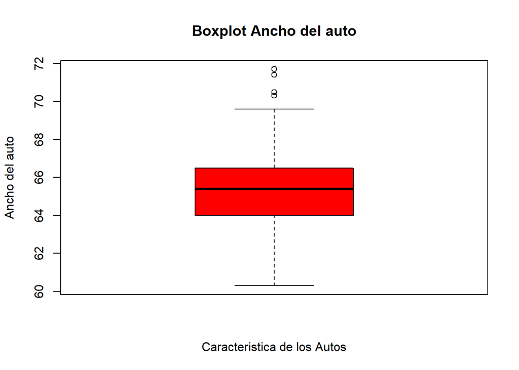

```r
boxplot(autosUsados_sNA$ancho, ylab="Ancho del auto", xlab="Caracteristica de los Autos", main="Boxplot Ancho del auto", col = "red" )
```

## Sexta Variable (Alto):

### Descriptores numéricos:

```r
summary(autosUsados_sNA$alto)
```

```
##    Min. 1st Qu.  Median    Mean 3rd Qu.    Max.
##   49.40   52.00   54.10   53.77   55.50   59.80
```

Media->podemos observar que los datos estan alrededor de 53.77 Mediana->podemos observar que al menos la mitad de los datos son mayores o iguales 54.10. 3re Quantil-> 75% de los datos es menor que o igual a 55.50. Min->el minimo valor es 49.40. Max->el máximo valor es 59.8.

#### Hallamos los quartiles:

```r
quantile(autosUsados_sNA$alto)
```

```
##   0%  25%  50%  75% 100%
## 49.4 52.0 54.1 55.5 59.8
```

Podemos observar que la mediana siempre será igual al cuartil del 50% o al segundo cuartil.

#### Valores Atípicos:

```r
boxplot.stats(autosUsados_sNA$alto)
```

```
## $stats
## [1] 49.4 52.0 54.1 55.5 59.8
##
## $n
## [1] 164
##
## $conf
## [1] 53.66818 54.53182
##
## $out
## numeric(0)
```

### Descriptores Gráficos:

#### Diagrama de caja:

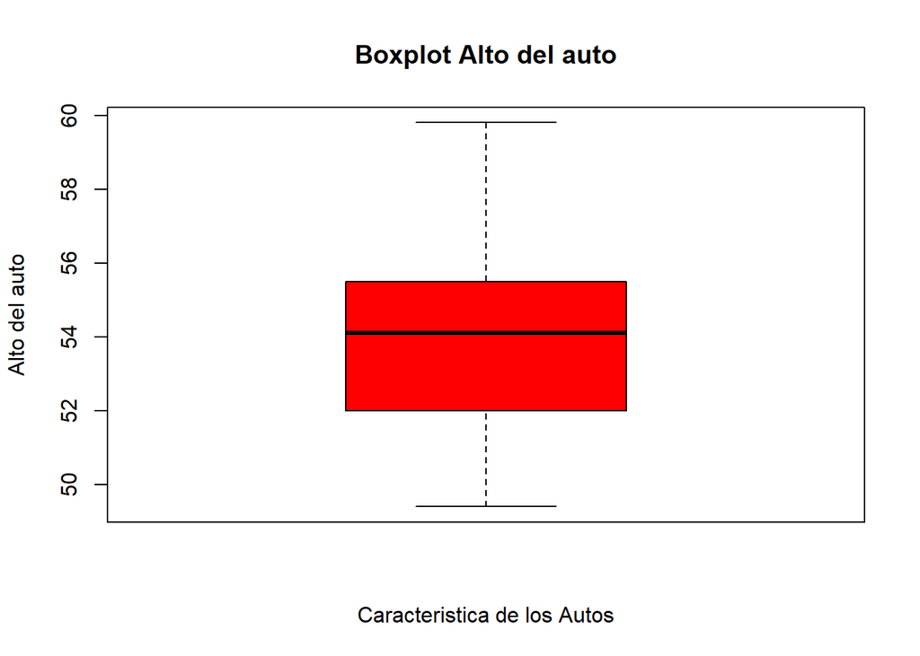

```r
boxplot(autosUsados_sNA$alto, ylab="Alto del auto", xlab="Caracteristica de los Autos", main="Boxplot Alto del auto", col = "red")
```

### Descriptores numéricos:

```r
summary(autosUsados_sNA$caballo_de_fuerza)
```

```
##    Min. 1st Qu.  Median    Mean 3rd Qu.    Max.
##   48.00   69.00   91.00   96.21  114.00  200.00
```

Media->podemos observar que los datos estan alrededor de 96.21 Mediana->podemos observar que al menos la mitad de los datos son mayores o iguales 91. 3re Quantil-> 75% de los datos es menor que o igual a 114. Min->el minimo valor es 48. Max->el máximo valor es 200.

#### Hallamos los quartiles:

```r
quantile(autosUsados_sNA$caballo_de_fuerza)
```

```
##   0%  25%  50%  75% 100%
##   48   69   91  114  200
```

Podemos observar que la mediana siempre será igual al cuartil del 50% o al segundo cuartil. #### Valores Atipicos:

```r
boxplot.stats(autosUsados_sNA$caballo_de_fuerza)
```

```
## $stats
## [1]  48  69  91 114 176
##
## $n
## [1] 164
##
## $conf
## [1] 85.44802 96.55198
##
## $out
## [1] 200
```

### Descriptores Gráficos:

#### Diagrama de caja:

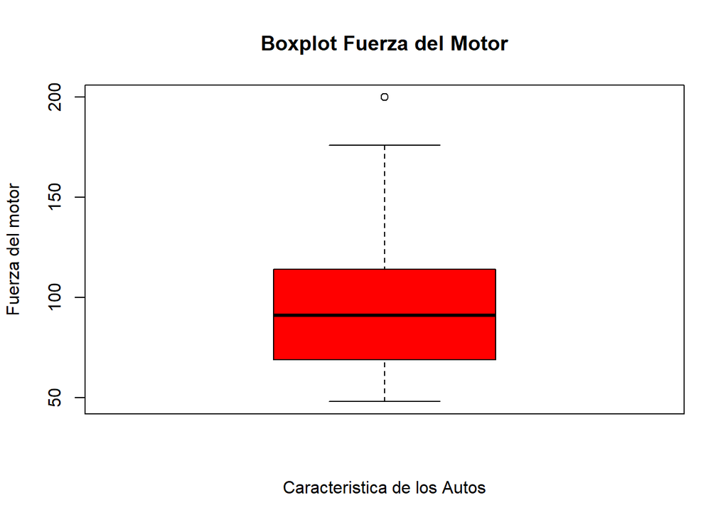

```r
boxplot(autosUsados_sNA$caballo_de_fuerza, ylab="Fuerza del motor", xlab="Caracteristica de los Autos", main="Boxplot Fuerza del Motor", col = "red" )
```

## Novena Variable (Tamanho_motor):

### Descriptores numéricos:

```r
summary(autosUsados_sNA$tamanho_motor)
```

```
##    Min. 1st Qu.  Median    Mean 3rd Qu.    Max.
##    61.0    97.0   109.0   118.0   131.8   258.0
```

Media->podemos observar que los datos estan alrededor de 118 Mediana->podemos observar que al menos la mitad de los datos son mayores o iguales 109.0. 3re Quantil-> 75% de los datos es menor que o igual a 131.8. Min->el minimo valor es 61.0. Max->el máximo valor es 258. #### Hallamos los quartiles:

```r
quantile(autosUsados_sNA$tamanho_motor)
```

```
##     0%    25%    50%    75%   100%
##  61.00  97.00 109.00 131.75 258.00
```

Podemos observar que la mediana siempre será igual al cuartil del 50% o al segundo cuartil. #### Valores Atipicos:

```r
boxplot.stats(autosUsados_sNA$tamanho_motor)
```

```
## $stats
## [1]  61.0  97.0 109.0 132.5 183.0
##
## $n
## [1] 164
##
## $conf
## [1] 104.6201 113.3799
##
## $out
## [1] 258 234
```

### Descriptores Gráficos:

#### Diagrama de caja:

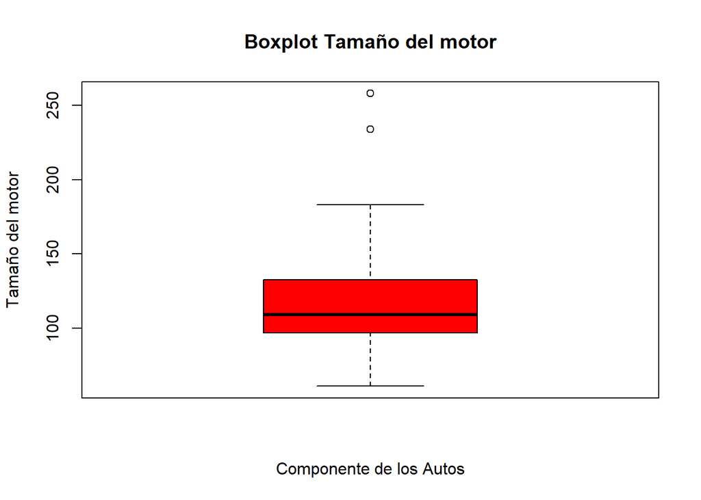

```r
boxplot(autosUsados_sNA$tamanho_motor, ylab="Tamaño del motor", xlab="Componente de los Autos", main="Boxplot Tamaño del motor", col = "red" )
```

## Décima Variable (Precio_carro):

### Descriptores numéricos:

```r
summary(autosUsados_sNA$precio_carro)
```

```
##    Min. 1st Qu.  Median    Mean 3rd Qu.    Max.
##    5118    7446    9268   11467   14559   35056
```

Media->podemos observar que los datos estan alrededor de 11467 Mediana->podemos observar que al menos la mitad de los datos son mayores o iguales 9268. 3re Quantil-> 75% de los datos es menor que o igual a 14559. Min->el minimo valor es 5118. Max->el máximo valor es 35056. #Hallamos los quartiles:

```r
quantile(autosUsados_sNA$precio_carro)
```

```
##       0%      25%      50%      75%     100%
##  5118.00  7446.00  9268.50 14559.25 35056.00
```

Podemos observar que la mediana siempre será igual al cuartil del 50% o al segundo cuartil.

#Valores Atipicos:

```r
boxplot.stats(autosUsados_sNA$precio_carro)
```

```
## $stats
## [1]  5118.0  7429.0  9268.5 14719.5 25552.0
##
## $n
## [1] 164
##
## $conf
## [1]  8369.018 10167.982
##
## $out
## [1] 32250 28248 28176 31600 35056
```

#Descriptores Gráficos:

#Diagrama de caja:

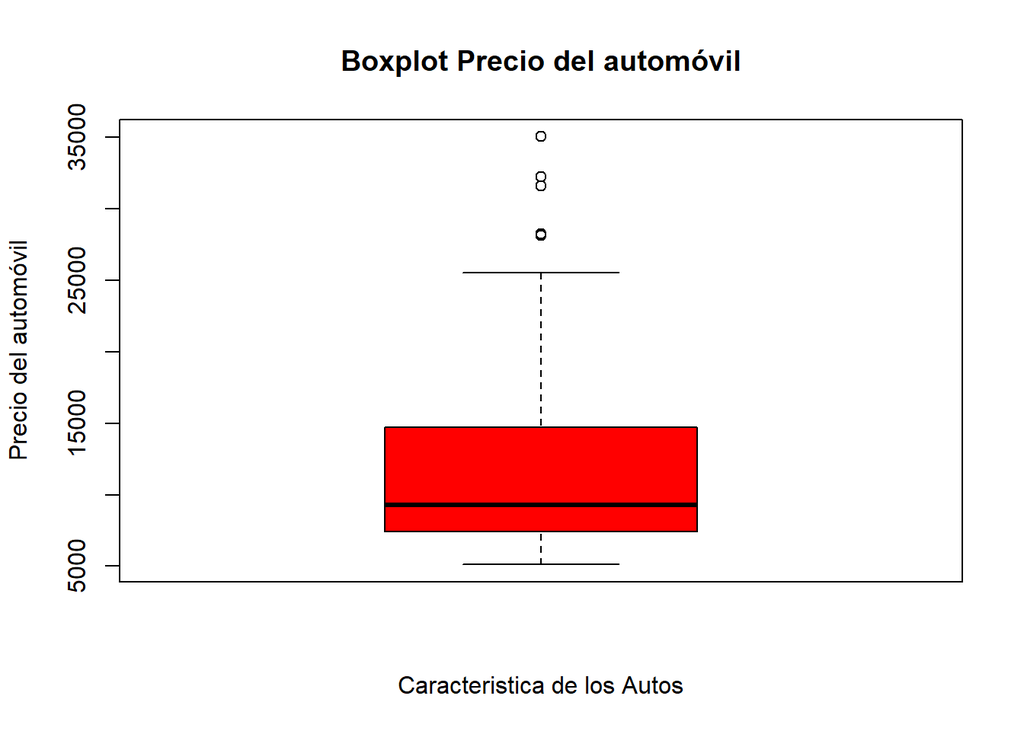

```r
boxplot(autosUsados_sNA$precio_carro, ylab="Precio del automóvil", xlab="Caracteristica de los Autos", main="Boxplot Precio del automóvil", col = "red" )
```

## Variable once (L_ciudad/100km):

### Descriptores numéricos:

```r
summary(autosUsados_sNA$`L_ciudad/100km`)
```

```
##    Min. 1st Qu.  Median    Mean 3rd Qu.    Max.
##   4.796   7.581   9.038   9.442  10.682  15.667
```

Media->podemos observar que los datos estan alrededor de 9.442 Mediana->podemos observar que al menos la mitad de los datos son mayores o iguales 9.03. 3re Quantil-> 75% de los datos es menor que o igual a 10.68. Min->el minimo valor es 4.796. Max->el máximo valor es 15.667.

#### Hallamos los quartiles:

```r
quantile(autosUsados_sNA$`L_ciudad/100km`)
```

```
##        0%       25%       50%       75%      100%
##  4.795918  7.580645  9.038462 10.681818 15.666667
```

Podemos observar que la mediana siempre será igual al cuartil del 50% o al segundo cuartil. #### Valores Atipicos:

```r
boxplot.stats(autosUsados_sNA$`L_ciudad/100km`)
```

```
## $stats
## [1]  4.795918  7.580645  9.038462 10.681818 14.687500
##
## $n
## [1] 164
##
## $conf
## [1] 8.655847 9.421076
##
## $out
## [1] 15.66667
```

### Descriptores Gráficos:

#### Diagrama de caja:

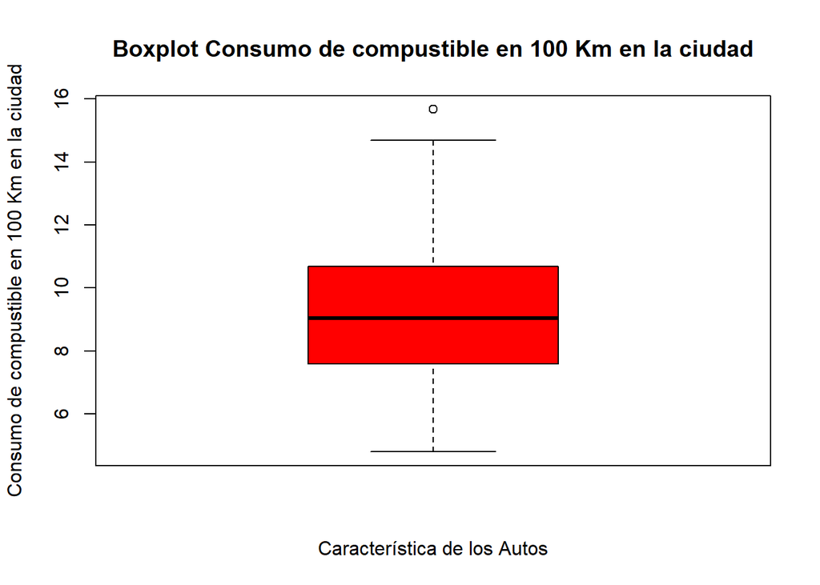

```r
boxplot(autosUsados_sNA$`L_ciudad/100km`, ylab="Consumo de compustible en 100 Km en la ciudad", xlab="Característica de los Autos", main="Boxplot Consumo de compustible en 100 Km en la ciudad", col = "red" )
```

## Segunda Variable (tipo_carroceria): ### Moda

```r
ModaCreada <- function(x) {
  DatosSinNulos <- na.omit(unique(x))
  tabulado <- tabulate(match(x, DatosSinNulos))
  DatosSinNulos[tabulado == max(tabulado) ]
}

ModaCreada(autosUsados_sNA$tipo_carroceria)
```

```
## [1] "sedan"
```

## Descriptores Gráficos:

### Tabla de Frecuencia:

```r
tabla_carr <- as.data.frame(table(autosUsados_sNA$tipo_carroceria))
transform(tabla_carr,
          FreqAC=cumsum(tabla_carr$Freq),
          Rel=round(prop.table(tabla_carr$Freq),3),
          RelAC=round(cumsum(prop.table(tabla_carr$Freq)),3))
```

| Var1 | Freq | FreqAC | Rel | RelAC |
| --- | --- | --- | --- | --- |
| convertible | 2 | 2 | 0.012 | 0.012 |
| hardtop | 5 | 7 | 0.030 | 0.043 |
| hatchback | 60 | 67 | 0.366 | 0.409 |
| sedan | 80 | 147 | 0.488 | 0.896 |
| wagon | 17 | 164 | 0.104 | 1.000 |

```r
#hist(x = tabla_carr$Freq, xlab = "Carroceria", ylab = "Frecuencias", main = "Tipo de Carroceria", col="orange")
```

## Tercera Variable (fabricante):

### Moda

```r
ModaCreada <- function(x) {
  DatosSinNulos <- na.omit(unique(x))
  tabulado <- tabulate(match(x, DatosSinNulos))
  DatosSinNulos[tabulado == max(tabulado) ]
}

ModaCreada(autosUsados_sNA$fabricante)
```

```
## [1] "toyota"
```

## Descriptores Gráficos:

### Tabla de Frecuencia:

```r
tabla_fa <- as.data.frame(table(autosUsados_sNA$fabricante))
transform(tabla_fa,
          FreqAC=cumsum(tabla_fa$Freq),
          Rel=round(prop.table(tabla_fa$Freq),3),
          RelAC=round(cumsum(prop.table(tabla_fa$Freq)),3))
```

| Var1 | Freq | FreqAC | Rel | RelAC |
| --- | --- | --- | --- | --- |
| audi | 4 | 4 | 0.024 | 0.024 |
| bmw | 4 | 8 | 0.024 | 0.049 |
| chevrolet | 3 | 11 | 0.018 | 0.067 |
| dodge | 9 | 20 | 0.055 | 0.122 |
| honda | 13 | 33 | 0.079 | 0.201 |
| jaguar | 1 | 34 | 0.006 | 0.207 |
| mazda | 15 | 49 | 0.091 | 0.299 |
| mercedes-benz | 5 | 54 | 0.030 | 0.329 |
| mitsubishi | 10 | 64 | 0.061 | 0.390 |
| nissan | 18 | 82 | 0.110 | 0.500 |

[output cut: 8 more lines]

```r
#hist(x = tabla_fa$Freq, xlab = "fabricante", ylab = "Frecuencias", main = "Marcas de Automóviles", col="purple")
```

## Septimo variable (Tipo_de_motor):

### Moda:

```r
ModaCreada <- function(x) {
  DatosSinNulos <- na.omit(unique(x))
  tabulado <- tabulate(match(x, DatosSinNulos))
  DatosSinNulos[tabulado == max(tabulado) ]
}

ModaCreada(autosUsados_sNA$tipo_de_motor)
```

```
## [1] "ohc"
```

## Descriptores Gráficos:

### Tabla de Frecuencia:

```r
tabla_moto <- as.data.frame(table(autosUsados_sNA$tipo_de_motor))
transform(tabla_fa,
          FreqAC=cumsum(tabla_moto$Freq),
          Rel=round(prop.table(tabla_moto$Freq),3),
          RelAC=round(cumsum(prop.table(tabla_moto$Freq)),3))
```

[output not shown]

[output cut: 8 more lines]

```r
#hist(x = tabla_moto$Freq, xlab = "Motor del Automovil", ylab = "Frecuencias", main = "Tipo de Motor", col="green")
```